# Coursework Report - Candidate number 218294

*N* removed NAs: 2

*N* removed typo: 1

*N* removed <18: 21

*N* total clean: 126

| Group | *N* | *M*<sub>age</sub> | *M*<sub>rating</sub> |
| --- | --- | --- | --- |
| Control | 61 | 20.9 | 5.43 |
| Experim | 65 | 21.2 | 6.55 |

**Main analysis results**

*t*(124) = -8.94, *p* < .001

[interactive chart not shown]

[figure not shown]

[interactive chart not shown]

# Coursework Report - Candidate number 218294

Analysing Data, Spring 2020

# Method

## Participants

Data was initially collected from 150 participants. However, 21 participants were removed due to being under the age of eighteen, 1 participant provided an invalid age due to mis-typing and 2 participants chose not to provide their age. This left a final sample of 126 participants (*M*<sub>age</sub> = 21.09, *SD*<sub>age</sub> = 2.07, *Min*<sub>age</sub> = 18, *Max*<sub>age</sub> = 27), whose data is included in the results.

Figure 1: shows the minimum, maximum and mean participant age.

| Mean | SD | Min-age | Max-age |
| --- | --- | --- | --- |
| 21.1 | 2.07 | 18 | 27 |

## Design

The question this research attempts to consider is whether colour influences women’s perceptions of a man’s attractiveness.

Variables in the study must be operationalised in order to be useful in analysis and to enable conclusions to be formed from obtained data.

The independent variable (predictor) in this study is the colour associated with the male figure. To operationalise this variable the colour of the frame surrounding the image will be either white, in the control condition, or red, in the experimental condition. The predictor, in this case, is an independent categorical variable, as participants will either be assigned to the control or experimental condition.

The dependent variable (outcome) in this study is the attractiveness ratings given by participants. This will be operationalised by the calculation of a mean composite score of a participant’s responses to the questions: “How attractive do you think this person is?”, “How pleasant is this person to look at?” and “If I were to meet the person in this picture face to face, I would think he is attractive.” The answers to these questions were given on a scale from 1 to 9 with a score of 1 being not at all attractive and 9 being the extremely attractive, making this a continuous variable.

Therefore, the operational hypothesis for this study is that the colour red enhances women’s perceived attractiveness of men. To test this hypothesis, an independent-samples *t*-test examining the influence of colour condition on perceived attractiveness will be utilised to compare the mean responses from the control and experimental conditions.

# Results

Participants in the red (experimental) condition, compared to participants in the white (control) condition, rated the male as more attractive.

Figure 2: Mean attractiveness ratings in each condition

| Condition | Mean | SD |
| --- | --- | --- |
| control | 5.43 | 1.33 |
| experimental | 6.55 | 1.25 |

The results from a independent sample *t*-test show there was a significant difference in the mean composite attractiveness ratings of the red (experimental) versus white (control) colour conditions (*M* = 6.55) rather than white condition (*M* = 5.43). This difference in means was significant (*M*<sub>diff</sub> = 1.13, 95% CI [-0.88, -1.38], *t* (124) = -8.94, *p* = .0000000).

These results suggest that attractiveness ratings are higher in conjunction with the colour red than paired with a neutral colour (white).

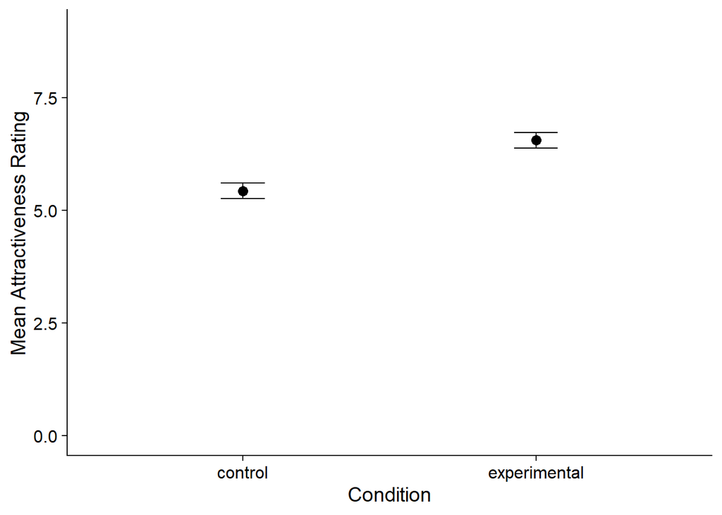

Figure 3: Mean attractiveness ratings in each condition

# Discussion

The results gathered in this study provide evidence for the proposed hypothesis that the colour red enhances women’s perceived attractiveness of men, as findings suggest women scored the male figure as being more attractive in the experimental condition (red), compared to the control group (white).

These results are in accordance with findings by Elliot, A. J., Kayser, D. N., Greitemeyer, T., Lichtenfeld, S., Gramzow, R. H., Maier, M. A., & Liu, H. (2010), which the present study is a replication of. This demonstrates high concurrent validity between past research (Elliot et al., 2010) and this replication study, providing data for the potential red effect due to new complying evidence a decade on from the original research.

The findings in this study can potentially provide greater insight into the theory that the colour red is representative of raised status or passion, proposed by Aslam (2006). The result of this effect in present research, being higher attractiveness scores in the experimental condition, which potentially provides evidence for status as an antecedent of attraction. However, this is inferred, as this study is not explicit in containing any material or questioning regarding views on status or passion from participants. Therefore, future research is needed to establish greater understanding of this relationship between red and status, and its resulting impacts on attraction.

The red effect has also been found to have some prevalence in research by Re, D. E., Whitehead, R. D., Xiao, D., & Perrett, D. I. (2011); Pazda, A. D., & Elliot, A. J. (2016) and Guéguen, N. (2012), whose findings support the hypothesis that the colour red (either redness in the face, a written suggestion of red or red clothing) have a positive impact on perceived attractiveness. Therefore, this indicates that the present study contributes to the body of research in this area, as it provides more contemporary evidence towards the red effect with the use of replicated methodologies and design of an influential study in this field (Elliot et al., 2010). However, the subtle difference of the method in which colour is manipulated impacts on our ability to comment on findings from Re et al., 2011, as perhaps it is a different phenomena, for example a more biological impulse, impacting on attractiveness ratings of women with more redness in their faces, than simply the addition of a red frame of an image. In addition, Re et al., 2011 and Guéguen, N. (2012) investigated masculine attraction toward a female figure, whereas the present research in investigating feminine heterosexual attraction, this also limits the degree to which findings from each study can be related to the other. The investigation into colour effects in the context of homosexual attraction could be a fascinating area for future inquiry to widen the breadth of research in this field and gain a greater understanding of underlying theory.

The majority of studies conducted in this area of research have used student samples when gathering data (Elliot et al., 2010; Peperkoorn, L. S., Roberts, S. C., & Pollet, T. V, 2016). This can be considered to be a drawback as perception of attractiveness may change across a person’s lifetime. Therefore, perhaps future research within this field could aim to investigate these temporal changes as well as employing cross-cultural measures to investigate the universality of the red effect. These variables could be integral facets in understanding the differences in the way attractiveness is perceived around the world, as well as the similarities we all share, regardless of cultural background.

A key strength of the present research derives from the use of an experimental design to attempt to ascertain a causal relationship between the colour red and attractiveness scores. The experimental method has been utilised by many key studies in this area (Elliot et al., 2010; Peperkoorn et al., 2016; Townsend & Levy, 1990b) and is useful in its ability to control the effects of extraneous variables on the outcome, enhancing internal validity. Moreover, the between groups design attempts to limit order effects, potentially lowering differential mortality rates as participants are less likely to become fatigued or work out the true aim of the study. Also, a large pool of quantitative data was collected, meaning data can be analysed statistically and conclusions can be derived from statistical tests of significance. This is an important advantage to consider when attempting to understand relationships between colour condition and perceived attractiveness, as statistical significance enables mathematical comparison between past and present research.

However, experimental control does not come without its costs. Ethically speaking, there is necessary deception incurred to prevent demand characteristics, however, due to the stringent control of experimental environment, participants may become aware of being studied, leading to the prevalence of demand characteristics within the sample. This could lower ecological validity and make any findings less applicable to target populations. Consequently, future research in this area should aim to combine methodologies and collate data from various studies across time to perform meta-analyses, establishing the effect colour has on attraction using a number of experimental designs.

In conclusion, this study adds to the pool of evidence suggesting that the presence of the colour red increases women’s perceived attractiveness of men. But in the investigation of this connection, interesting and thought provoking ideas have been raised into the ways in which colour can be the courier of subtle and distinct meaning, unconsciously, between the sexes. The future of this field of research is promising, as present research leaves many questions unanswered, both in methodology and in theory. For example, cross-cultural and temporal dependents on colour and attraction, the investigation into whether findings can be applied to homosexual participants, in addition to the view of status as an antecedent of attraction in a contemporary context.

# References

Aslam, M. M. (2006). Are You Selling the Right Colour? A Cross‐cultural Review of Colour as a Marketing Cue. *Journal of Marketing Communications, 12(1), 15–30. doi: 10.1080/13527260500247827*

Elliot, A. J., Niesta Kayser, D., Greitemeyer, T., Lichtenfeld, S., Gramzow, R. H., Maier, M. A., & Liu, H. (2010). Red, rank, and romance in women viewing men. *Journal of Experimental Psychology: General, 139*(3), 399.

Guéguen, N. (2012). Color and Women Attractiveness: When Red Clothed Women Are Perceived to Have More Intense Sexual Intent. *The Journal of Social Psychology, 152(3), 261–265. doi: 10.1080/00224545.2011.605398*

Pazda, A. D., & Elliot, A. J. (2016). Processing the Word Red can Enhance Women’s Perceptions of Men’s Attractiveness. *Current Psychology, 36(2), 316–323. doi: 10.1007/s12144-016-9420-8*

Peperkoorn, L. S., Roberts, S. C., & Pollet, T. V. (2016). Revisiting the Red Effect on Attractiveness and Sexual Receptivity. *Evolutionary Psychology, 14(4), 147470491667384. doi: 10.1177/1474704916673841*

Re, D. E., Whitehead, R. D., Xiao, D., & Perrett, D. I. (2011). Oxygenated-Blood Colour Change Thresholds for Perceived Facial Redness, Health, and Attractiveness. *PLoS ONE, 6(3). doi: 10.1371/journal.pone.0017859*

Townsend, J. M., & Levy, G. D. (1990). Effects of potential partners physical attractiveness and socioeconomic status on sexuality and partner selection. *Archives of Sexual Behavior, 19(2), 149–164. doi: 10.1007/bf01542229*